# Simulação com o R

Análise de Dados Financeiros e Econômicos com o R

Marcelo S. Perlin

EA-UFRGS

05/11/2026

# Concepts

## Introduction

> Simulation is the act of creating, artificially, possible paths (behavior) of a system subject to uncertainty (Brooks 2014).
- Any system of stochastic (random) equations can be simulated with code (and R)
- Applications of simulation in empirical problems (including Finance) are widespread

## Calculating pi

Estimating a deterministic quantity with random draws (Monte Carlo):

$$P(\text{point inside the circle}) = \frac{\pi}{4} \quad \Rightarrow \quad \hat{\pi} = 4 \times \frac{\text{hits}}{M}$$

[video not shown]

## Calculating pi - animation

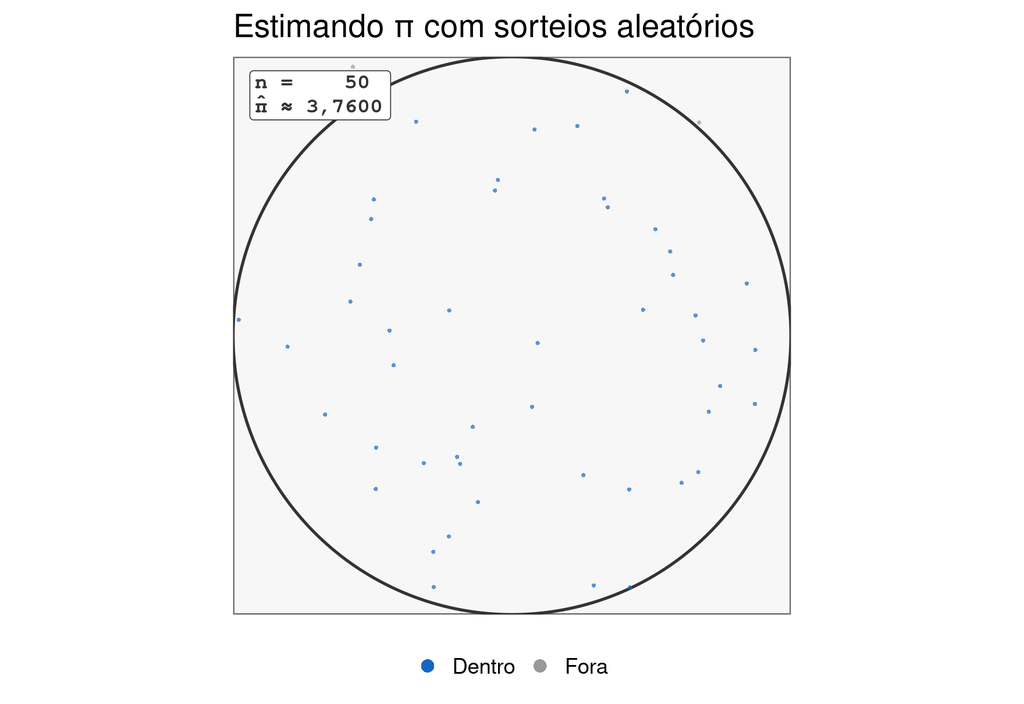

Each dot is one random draw; the estimate is 4 × (dots inside the circle) / total.

## Simulating behavior in nature

[video not shown]

## AI learning from Simulations

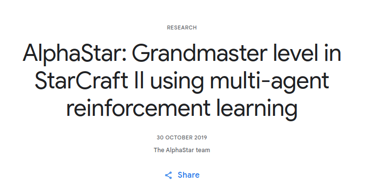

Source [report](https://deepmind.google/discover/blog/alphastar-grandmaster-level-in-starcraft-ii-using-multi-agent-reinforcement-learning/) from Google Deepmind

## Applications in Finance:

- Pricing derivative contracts (options, swaps, …)
- Finding moments and probabilities of complex systems of equations (e.g. payments system)
- Project analysis (NPV & IRR) under uncertainty
- Econometrics (bootstrap and pricing models)
- Performance analysis of a trading strategy

## A (biased) set of examples in applied research

- Simulation of an operational failure in UK’s payments system – [System-Wide liquidity risk in the UK’s large-value payment system: an empirical analysis](https://www.bankofengland.co.uk/-/media/boe/files/working-paper/2011/system-wide-liquidity-risk-in-the-uks-large-value-payment-system-an-empirical-analysis.pdf)
- Simulating Ibovespa recovery after Covid – [A GARCH Tutorial with R](https://rac.anpad.org.br/index.php/rac/article/view/1420/1517)
- Simulating financial markets and a retirement portfolio – [What is the sustainable withdraw rate for Brazil?](https://periodicos.fgv.br/rbfin/article/view/89040)
- Randomized sampling for comparable peers – [The determinants and impact of research grants: The case of Brazilian productivity scholarships](https://www.sciencedirect.com/science/article/pii/S1751157724000762?via%3Dihub#se0040)

## Steps for a simulation

1. Define or estimate a mathematical structure of the data generating process;
2. Simulate the system of equations a reasonable amount of times and save the measure of interest at the end of each simulation;
3. Repeat steps 1 and 2 many times;

# Simulating with R

## Random sampling in R

We always assume that the distribution of the random variables is known (or approximated by):

- Symmetric: Uniform, Normal, Student’s t, Beta, etc
- Positive: exponential, Gamma, Weibull, etc
- Many more

In R, every distribution has a `r` function: `rnorm()`, `runif()`, `rgamma()`, `rbeta()`, …

## Random sampling in R - Examples

- Normal Distribution
- Gamma
- Uniform
- Beta

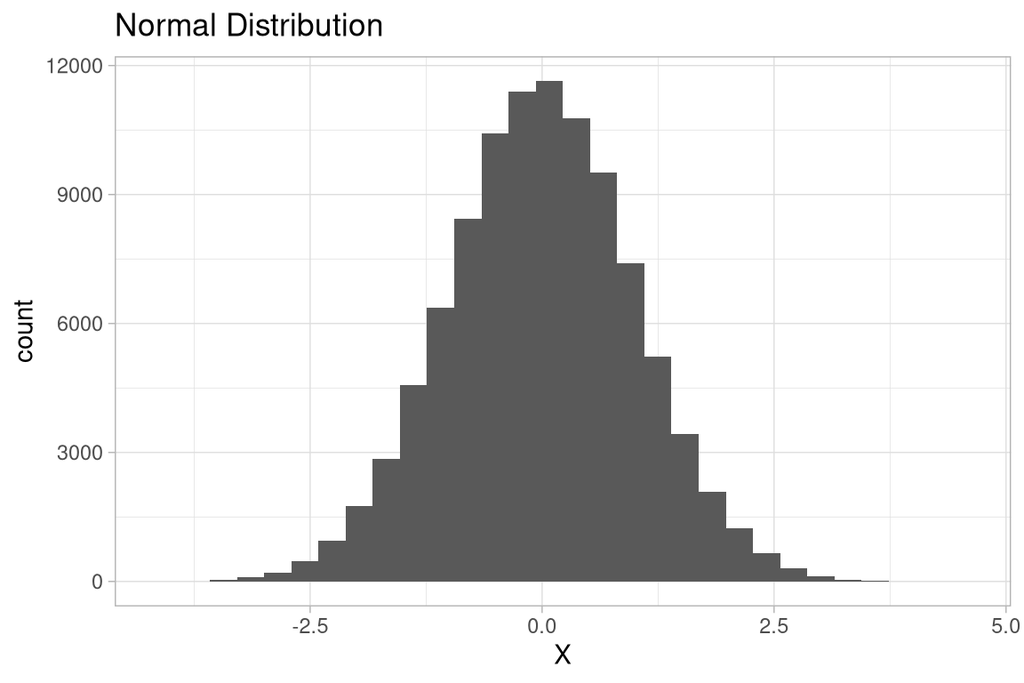

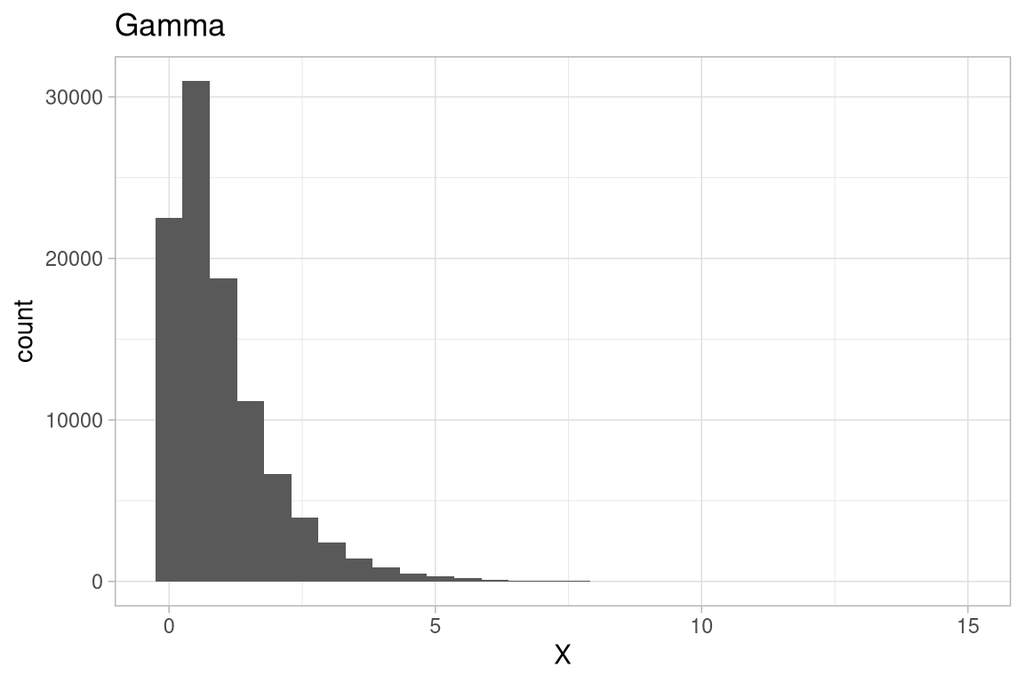

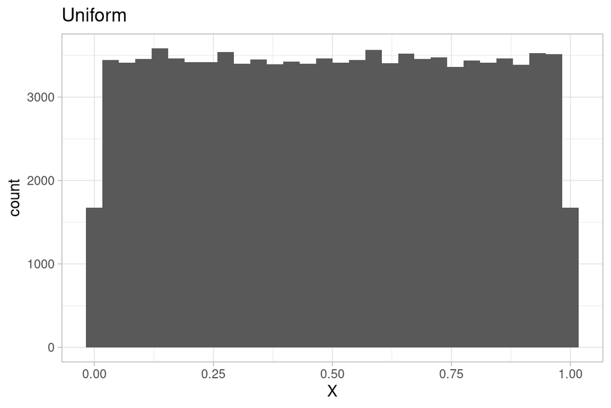

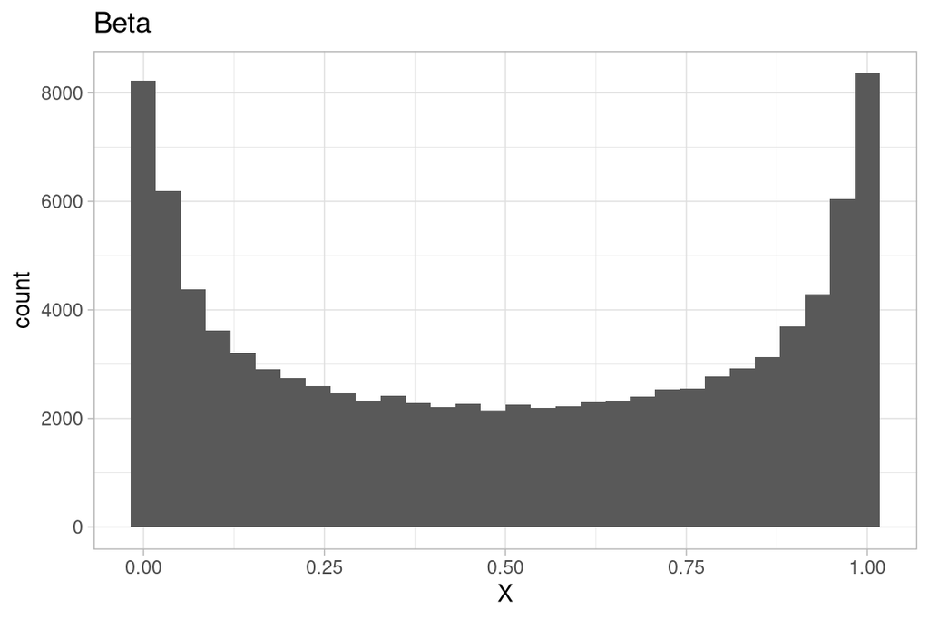

## How many simulations are enough?

Each simulation result is an **estimate**: it changes if you change the seed. Its precision is measured by the **Monte Carlo standard error**:

$$SE(\hat{\theta}) = \frac{SD\left(\hat{\theta}_i\right)}{\sqrt{M}}$$

- Quadrupling `M` only halves the error: accuracy is expensive
- The estimate is ~95% within $\pm 1.96 \times SE$ of the true value
- Always report the estimate **and** its Monte Carlo error

## Convergence in practice

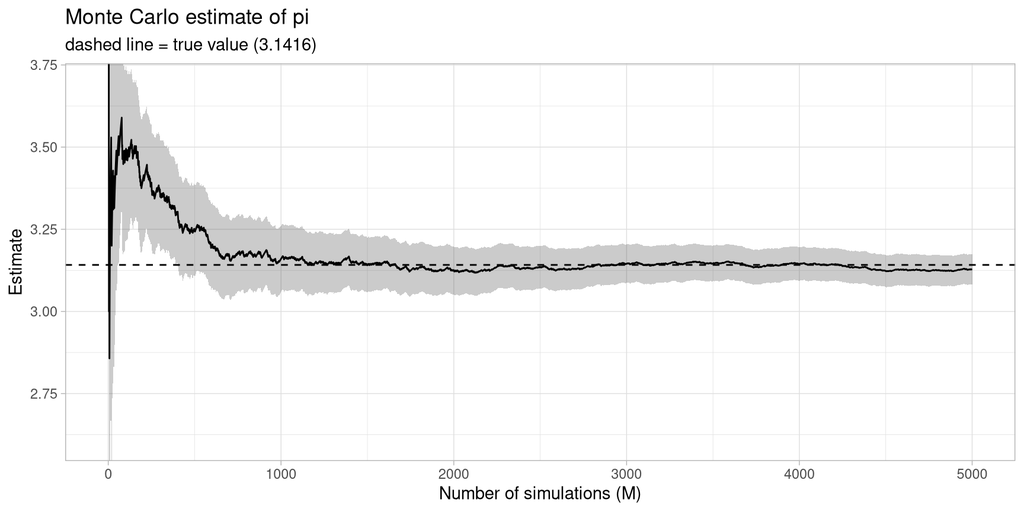

Estimate: 3.129 | Monte Carlo error: 0.023 | True value: 3.1416

## A simple regression model

$y _i = \alpha + \beta x_i + \epsilon _i$

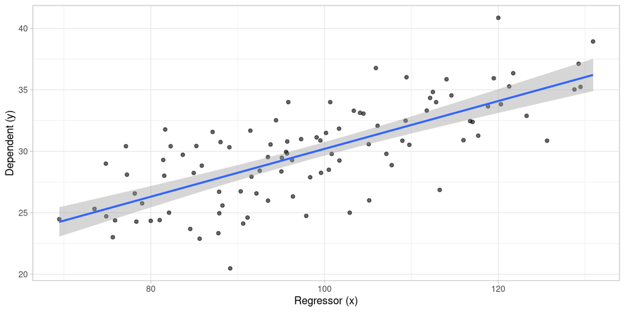

Simulated data (points) and the fitted regression line

## A simple stochastic process in Finance

The discrete *Random Walk* Model

$$\begin{eqnarray}
P_t&=&P_{t-1} \exp (R_t) \\
R_t &=& C + \epsilon _t \\
\epsilon _t &\sim& N\left(0,\sigma ^2 \right)
\end{eqnarray}$$

where $P_t$ is the price of the contract, $R_t$ is the return (daily, monthly, ..)

A bit of math shows that:

- Since $E(R_t)=C$, you cannot predict $P_{t+1}$
- Since $\sigma(R_t)=\sigma(\epsilon _t)$, variance (uncertainty) per period is constant and increases with forecasting horizon

## Exercise 1 - Creating a Random Walk

1. Using a loop, create script ADFER-Exercicio-Aula-10-Simulação_1.R
2. Within the script, simulate 100 prices of the following random walk model (use `set.seed(1)`). Note that `P_0 = 100` is the first element of the vector, so you only need to simulate 99 returns:

$$\begin{eqnarray}
R_t &=& 0.005 + \epsilon _t \\
\epsilon _t &\sim& N \left(0, \sigma ^2 \right) \\
P_t&=&P_{t-1} \exp (R_t) \\
P_0 &=& 100 \\
\sigma &=& 0.015
\end{eqnarray}$$

3. With `ggplot2`, create a figure to represent the path of prices over time (use a sequence of dates as the x axis)

## Exercise 2 - Simulating many random walks

1. Based on previous exercise, create 1000 vectors of prices with the same random walk model with 100 time periods and save it in a `tibble` in the long format.
2. Using `ggplot2`, create a single figure with the prices of all stocks

# Applications

## Pricing European Options with Simulation

A call option of the European type is a financial contract where the payoff is a function of the spot price:

$$\begin{equation}
Payoff^C _T = \max(0 , P_T - K)
\end{equation}$$

$Payoff^C _T$ - Payoff (payment) of call option

$P_T$ - Price of underlying asset in maturity ($T$)

$K$ - Strike price of contract

## Pricing the option with simulation

We can calculate the price (Expected payoff) of this call option by simulating stock prices and calculating the simulated payoff at the expiration date

$$C = \frac{E\left[Payoff_T\right]}{(1+r)^T}$$

where $r$ is the discount rate per period. With continuous compounding, $C = e^{-rT} E\left[Payoff_T\right]$.

**Note**

The simulated prices use a zero drift ($C = 0$), i.e. we are assuming the risk-neutral measure.

## Exercise 3 - Pricing a Call option

Consider the following RW model

$$\begin{eqnarray}
R_t &=& 0 + \epsilon _t \\
\epsilon _t &\sim& N\left(0, \sigma ^2 \right) \\
P_t&=&P_{t-1} \exp (R_t) \\
P_0 &=& 100 \\
\sigma &=& 0.015
\end{eqnarray}$$

1. Calculate the price of the call option with maturity in 100 periods, strike price equal to 110, yield rate equal to 5% for the whole time period. Use `set.seed(10)` and 1000 simulations
2. Price an European put option that matures in 100 periods, strike price equal to 90, with 1000 simulations and `set.seed(15)`

## Solution - Pricing the call option

```r
set.seed(10)

M <- 1000; nT <- 100
P_0 <- 100; sigma <- 0.015
K <- 110; r <- 0.05

R <- matrix(rnorm(M*nT, 0, sigma), M, nT)
P_T <- P_0 * exp(rowSums(R))
C <- mean(pmax(P_T - K, 0))/(1 + r)
C
```

```
[1] 2.301126
```

The result is deterministic given the seed. Change the seed (or `M`) and the last digits will change.

## Exercise 4 - Simulating Ibovespa

Consider the following RW model:

$$\begin{eqnarray}
R_t &=& C + \epsilon _t \\
\epsilon _t &\sim& N\left(0, \sigma^2 \right) \\
P_t&=&P_{t-1} \exp (R_t) \\
\end{eqnarray}$$

1. Use package `yfR` (Perlin 2023) to download daily data for Ibovespa (`^BVSP`) in the last 3 years (`Sys.Date() - 365*3`), e.g. with `yfR::yf_get(tickers = "^BVSP", first_date = Sys.Date() - 365*3)`
2. Estimate parameters $C$ and $\sigma$ for the Ibovespa index as:

$$\begin{eqnarray}
R_t &=& log(\frac{P_t}{P_{t-1}}) \\
C &=& E(R_t) \\
\sigma &=& SD(R_T)
\end{eqnarray}$$

3. Using the parameters from the estimation, simulate the prices of Ibovespa for the next 100 days. TIP: Use the last available price as $P_0$.
4. Create a figure with `ggplot2`, showing all possible paths of the simulation.

# Bootstrap

## Bootstrapping standard errors

One of the outputs of a linear regression is the standard error of each coefficient.

Consider a scenario where we are interested in a transformation of the parameters, such as:

$$\begin{eqnarray}
y_t &=& \alpha + \beta _1 x_{1,t} + \beta _2 x_{2,t} + \epsilon _t \\
\Theta &=& \frac{\beta _1 - \beta _2}{\alpha}
\end{eqnarray}$$

**How to find the standard error of $\Theta$?**

## Bootstrapping standard errors

1. Estimate the original model and save the created (conditional mean, $\hat{y}_t$) and the vector of residuals, $\hat{\epsilon}_t$
2. Create a second variable $y^*$ given by:

$$\begin{equation}
y^*_t = \hat{y}_t + \epsilon ^* _t
\end{equation}$$

where $\epsilon ^* _t$ is a resampled vector of $\hat{\epsilon}_t$ (same size, with replacement: `sample(res, replace = TRUE)`)

3. Estimate the econometric model:

$$y ^* _t = \alpha ^* + \beta ^* _1 x_{1,t} + \beta ^* _2 x_{2,t} + \epsilon _t$$

4. Calculate:

$$\Theta ^* = \frac{\beta ^* _1 - \beta ^* _2}{\alpha ^*}$$

5. Repeat steps 2, 3 and 4 `M` times, saving $\Theta ^*$ in each case
6. The final result will be a vector of $\Theta ^*$. Its standard error is simply the standard deviation of the vector

## Exercise 5 - Bootstrapping standard errors

1. With package `afedR3`, load the data from file `EX_Ibov_PETR4.csv` (`afedR3::data_path('EX_Ibov_PETR4.csv')`)
2. Estimate the market model for `PETR4`:

$$\begin{equation}
R_t = \alpha + \beta R_{t,M} + \epsilon _t
\end{equation}$$

where $R_{t,M}$ is the return of Ibovespa

3. Using the bootstrap procedure described earlier, calculate the standard error of $\frac{\alpha}{\beta}$ with 1000 simulations

# Referências

Brooks, Chris. 2014. *Introductory Econometrics for Finance*. Cambridge university press.

Perlin, Marcelo. 2023. *yfR: Downloads and Organizes Financial Data from Yahoo Finance*. https://github.com/ropensci/yfR.